# Homework 2

## Homework 2 - Danielle Goedhart

**Question 1**

```r
library(nycflights13)
library(dplyr)
airlines <- airlines
airports <- airports
flights <- flights
planes <- planes
weather <- weather

top_destinations <- flights |>
  count(dest, sort = TRUE) |>
  slice_head(n = 10)

top_destinations
```

```
# A tibble: 10 × 2
   dest      n
   <chr> <int>
 1 ORD   17283
 2 ATL   17215
 3 LAX   16174
 4 BOS   15508
 5 MCO   14082
 6 CLT   14064
 7 SFO   13331
 8 FLL   12055
 9 MIA   11728
10 DCA    9705
```

1. The top 10 most popular destinations are: ORD, ATL, LAX, BOS, MCO, CLT, SFO, FLL, MIA, and DCA. ORD had 17283 flights, ATL had 17215, LAX had 16174, BOS had 15508, MCO had 14082, CLT had 14064, SFO had 13331, FLL had 12055, MIA had 11728, and DCA had 9705 flights in 2013.

**Question 2**

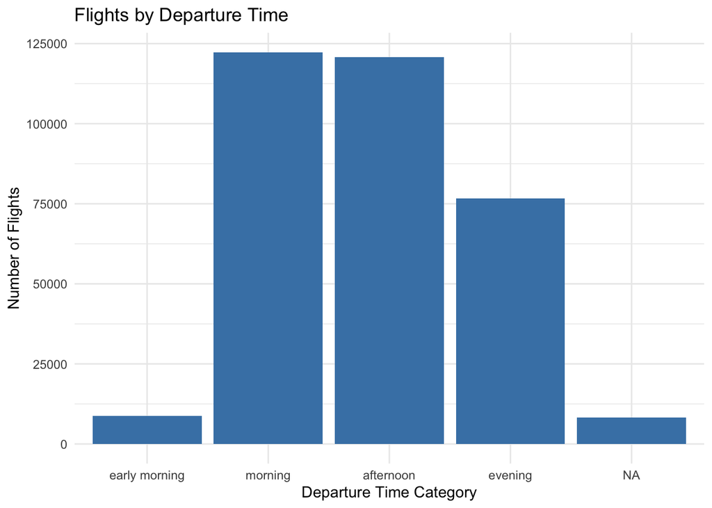

```r
library(dplyr)
flights_times <- flights |>
  mutate(
    dep_time_clean = dep_time %% 2400,
    arr_time_clean = arr_time %% 2400,

    dep_category = case_when(
      dep_time_clean < 600  ~ "early morning",
      dep_time_clean < 1200 ~ "morning",
      dep_time_clean < 1800 ~ "afternoon",
      dep_time_clean < 2400 ~ "evening",
      TRUE ~ NA_character_
    ),

    arr_category = case_when(
      arr_time_clean < 600  ~ "early morning",
      arr_time_clean < 1200 ~ "morning",
      arr_time_clean < 1800 ~ "afternoon",
      arr_time_clean < 2400 ~ "evening",
      TRUE ~ NA_character_
    )
  )

time_levels <- c(
  "early morning",
  "morning",
  "afternoon",
  "evening"
)

flights_times <- flights_times |>
  mutate(
    dep_category = factor(dep_category, levels = time_levels),
    arr_category = factor(arr_category, levels = time_levels)
  )

library(ggplot2)
ggplot(
  data = flights_times,
  aes(x = dep_category)
) +
  geom_bar(fill = "steelblue") +
  labs(
    title = "Flights by Departure Time",
    x = "Departure Time Category",
    y = "Number of Flights"
  ) +
  theme_minimal()
```

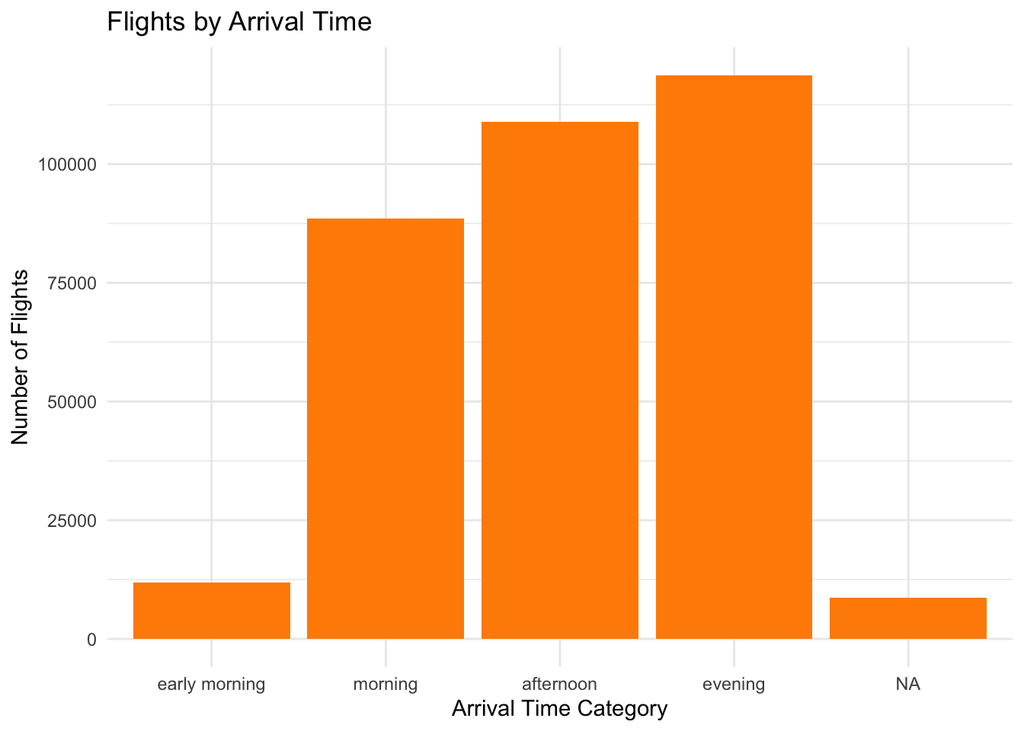

```r
ggplot(
  data = flights_times,
  aes(x = arr_category)
) +
  geom_bar(fill = "darkorange") +
  labs(
    title = "Flights by Arrival Time",
    x = "Arrival Time Category",
    y = "Number of Flights"
  ) +
  theme_minimal()
```

```r
flights_times <- flights_times |>
  mutate(
    red_eye = dep_category %in% c("afternoon", "evening") &
      arr_category %in% c("early morning", "morning")
  )

red_eye_summary <- flights_times |>
  filter(!is.na(dep_category), !is.na(arr_category)) |>
  summarize(
    total_flights = n(),
    red_eye_flights = sum(red_eye),
    red_eye_percentage = mean(red_eye) * 100
  )

red_eye_summary
```

```
# A tibble: 1 × 3
  total_flights red_eye_flights red_eye_percentage
          <int>           <int>              <dbl>
1        328063           10754               3.28
```

2. When looking at the bar plot for departure time. We can see that most flights departed in the morning or in the afternoon, both a little under 125000 flights. A big chunk, about 75000 flights, departed in the evening. Only a very small amount of flights departed in the early morning, and about the same amount was classified as NA. When looking at arrival time, most flights arrived in the evening. Then, the afternoon and morning had the most arrivals, in that order. Very little flights arrived in the early morning, and about the same amount was classified as NA. Out of the 328063 total flights, 10754 were red eye flights, which corresponds to 3.278% of all flights.

**Question 3**

```r
plane_airlines <- flights |>
  filter(!is.na(tailnum)) |>
  distinct(tailnum, carrier)

multiple_airline_planes <- plane_airlines |>
  group_by(tailnum) |>
  summarize(
    number_of_airlines = n_distinct(carrier),
    airline_codes = paste(sort(unique(carrier)), collapse = ", "),
    .groups = "drop"
  ) |>
  filter(number_of_airlines > 1)

multiple_airline_planes
```

```
# A tibble: 17 × 3
   tailnum number_of_airlines airline_codes
   <chr>                <int> <chr>
 1 N146PQ                   2 9E, EV
 2 N153PQ                   2 9E, EV
 3 N176PQ                   2 9E, EV
 4 N181PQ                   2 9E, EV
 5 N197PQ                   2 9E, EV
 6 N200PQ                   2 9E, EV
 7 N228PQ                   2 9E, EV
 8 N232PQ                   2 9E, EV
 9 N933AT                   2 DL, FL
10 N935AT                   2 DL, FL
11 N977AT                   2 DL, FL
12 N978AT                   2 DL, FL
13 N979AT                   2 DL, FL
14 N981AT                   2 DL, FL
15 N989AT                   2 DL, FL
16 N990AT                   2 DL, FL
17 N994AT                   2 DL, FL
```

```r
nrow(multiple_airline_planes)
```

```
[1] 17
```

```r
multiple_airline_details <- plane_airlines |>
  inner_join(airlines, by = "carrier") |>
  group_by(tailnum) |>
  summarize(
    number_of_airlines = n_distinct(carrier),
    airline_codes = paste(sort(unique(carrier)), collapse = ", "),
    airline_names = paste(sort(unique(name)), collapse = ", "),
    .groups = "drop"
  ) |>
  filter(number_of_airlines > 1)

multiple_airline_details
```

```
# A tibble: 17 × 4
   tailnum number_of_airlines airline_codes airline_names
   <chr>                <int> <chr>         <chr>
 1 N146PQ                   2 9E, EV        Endeavor Air Inc., ExpressJet Airli…
 2 N153PQ                   2 9E, EV        Endeavor Air Inc., ExpressJet Airli…
 3 N176PQ                   2 9E, EV        Endeavor Air Inc., ExpressJet Airli…
 4 N181PQ                   2 9E, EV        Endeavor Air Inc., ExpressJet Airli…
 5 N197PQ                   2 9E, EV        Endeavor Air Inc., ExpressJet Airli…
 6 N200PQ                   2 9E, EV        Endeavor Air Inc., ExpressJet Airli…
 7 N228PQ                   2 9E, EV        Endeavor Air Inc., ExpressJet Airli…
 8 N232PQ                   2 9E, EV        Endeavor Air Inc., ExpressJet Airli…
 9 N933AT                   2 DL, FL        AirTran Airways Corporation, Delta …
10 N935AT                   2 DL, FL        AirTran Airways Corporation, Delta …
11 N977AT                   2 DL, FL        AirTran Airways Corporation, Delta …
12 N978AT                   2 DL, FL        AirTran Airways Corporation, Delta …
13 N979AT                   2 DL, FL        AirTran Airways Corporation, Delta …
14 N981AT                   2 DL, FL        AirTran Airways Corporation, Delta …
15 N989AT                   2 DL, FL        AirTran Airways Corporation, Delta …
16 N990AT                   2 DL, FL        AirTran Airways Corporation, Delta …
17 N994AT                   2 DL, FL        AirTran Airways Corporation, Delta …
```

```r
nrow(multiple_airline_details)
```

```
[1] 17
```

3. Yes there were some planes that flew for multiple airlines. There were 17 airplanes that flew for multiple airlines. The table above shows each plane’s tail number, and the airlines it was flying for. The airlines that they flew for was either Endeavor Airlines and Expressjet Airlines or Delta and Airtran airways, those are the two possible combinations.

**Question 4**

There is a missing relationship between weather and airports. The missing relationship is between faa in airports and origin in the weather dataset. The origin variable in the weather dataset identifies where each weather observation was recorded, which corresponds to the faa variable in the airports dataset. Thus, there should be a branch airports$faa, with an arrow to weather$origin.

**Question 5**

```r
weather2 <- weather |>
  mutate(
    weather_id = paste(
      year, month, day, hour, origin,
      sep = "-"
    )
  )

sum(duplicated(weather2$weather_id))
```

```
[1] 3
```

```r
weather2 |>
  count(weather_id) |>
  filter(n > 1)
```

```
# A tibble: 3 × 2
  weather_id          n
  <chr>           <int>
1 2013-11-3-1-EWR     2
2 2013-11-3-1-JFK     2
3 2013-11-3-1-LGA     2
```

```r
weather2 |>
  group_by(weather_id) |>
  filter(n() > 1) |>
  select(
    weather_id,
    origin,
    year,
    month,
    day,
    hour,
    time_hour
  ) |>
  arrange(weather_id, time_hour)
```

```
# A tibble: 6 × 7
# Groups:   weather_id [3]
  weather_id      origin  year month   day  hour time_hour
  <chr>           <chr>  <int> <int> <int> <int> <dttm>
1 2013-11-3-1-EWR EWR     2013    11     3     1 2013-11-03 01:00:00
2 2013-11-3-1-EWR EWR     2013    11     3     1 2013-11-03 01:00:00
3 2013-11-3-1-JFK JFK     2013    11     3     1 2013-11-03 01:00:00
4 2013-11-3-1-JFK JFK     2013    11     3     1 2013-11-03 01:00:00
5 2013-11-3-1-LGA LGA     2013    11     3     1 2013-11-03 01:00:00
6 2013-11-3-1-LGA LGA     2013    11     3     1 2013-11-03 01:00:00
```

```r
weather_join <- weather |>
  select(
    origin,
    time_hour,
    temp,
    dewp,
    humid,
    wind_dir,
    wind_speed,
    wind_gust,
    precip,
    pressure,
    visib
  )

flights_weather <- flights |>
  left_join(
    weather_join,
    by = c("origin", "time_hour")
  )

glimpse(flights_weather)
```

```
Rows: 336,776
Columns: 28
$ year           <int> 2013, 2013, 2013, 2013, 2013, 2013, 2013, 2013, 2013, 2…
$ month          <int> 1, 1, 1, 1, 1, 1, 1, 1, 1, 1, 1, 1, 1, 1, 1, 1, 1, 1, 1…
$ day            <int> 1, 1, 1, 1, 1, 1, 1, 1, 1, 1, 1, 1, 1, 1, 1, 1, 1, 1, 1…
$ dep_time       <int> 517, 533, 542, 544, 554, 554, 555, 557, 557, 558, 558, …
$ sched_dep_time <int> 515, 529, 540, 545, 600, 558, 600, 600, 600, 600, 600, …
$ dep_delay      <dbl> 2, 4, 2, -1, -6, -4, -5, -3, -3, -2, -2, -2, -2, -2, -1…
$ arr_time       <int> 830, 850, 923, 1004, 812, 740, 913, 709, 838, 753, 849,…
$ sched_arr_time <int> 819, 830, 850, 1022, 837, 728, 854, 723, 846, 745, 851,…
$ arr_delay      <dbl> 11, 20, 33, -18, -25, 12, 19, -14, -8, 8, -2, -3, 7, -1…
$ carrier        <chr> "UA", "UA", "AA", "B6", "DL", "UA", "B6", "EV", "B6", "…
$ flight         <int> 1545, 1714, 1141, 725, 461, 1696, 507, 5708, 79, 301, 4…
$ tailnum        <chr> "N14228", "N24211", "N619AA", "N804JB", "N668DN", "N394…
$ origin         <chr> "EWR", "LGA", "JFK", "JFK", "LGA", "EWR", "EWR", "LGA",…
$ dest           <chr> "IAH", "IAH", "MIA", "BQN", "ATL", "ORD", "FLL", "IAD",…
$ air_time       <dbl> 227, 227, 160, 183, 116, 150, 158, 53, 140, 138, 149, 1…
$ distance       <dbl> 1400, 1416, 1089, 1576, 762, 719, 1065, 229, 944, 733, …
$ hour           <dbl> 5, 5, 5, 5, 6, 5, 6, 6, 6, 6, 6, 6, 6, 6, 6, 5, 6, 6, 6…
$ minute         <dbl> 15, 29, 40, 45, 0, 58, 0, 0, 0, 0, 0, 0, 0, 0, 0, 59, 0…
$ time_hour      <dttm> 2013-01-01 05:00:00, 2013-01-01 05:00:00, 2013-01-01 0…
$ temp           <dbl> 39.02, 39.92, 39.02, 39.02, 39.92, 39.02, 37.94, 39.92,…
$ dewp           <dbl> 28.04, 24.98, 26.96, 26.96, 24.98, 28.04, 28.04, 24.98,…
$ humid          <dbl> 64.43, 54.81, 61.63, 61.63, 54.81, 64.43, 67.21, 54.81,…
$ wind_dir       <dbl> 260, 250, 260, 260, 260, 260, 240, 260, 260, 260, 260, …
$ wind_speed     <dbl> 12.65858, 14.96014, 14.96014, 14.96014, 16.11092, 12.65…
$ wind_gust      <dbl> NA, 21.86482, NA, NA, 23.01560, NA, NA, 23.01560, NA, 2…
$ precip         <dbl> 0, 0, 0, 0, 0, 0, 0, 0, 0, 0, 0, 0, 0, 0, 0, 0, 0, 0, 0…
$ pressure       <dbl> 1011.9, 1011.4, 1012.1, 1012.1, 1011.7, 1011.9, 1012.4,…
$ visib          <dbl> 10, 10, 10, 10, 10, 10, 10, 10, 10, 10, 10, 10, 10, 10,…
```

```r
nrow(flights)
```

```
[1] 336776
```

```r
nrow(flights_weather)
```

```
[1] 336776
```

```r
flights_weather
```

```
# A tibble: 336,776 × 28
    year month   day dep_time sched_dep_time dep_delay arr_time sched_arr_time
   <int> <int> <int>    <int>          <int>     <dbl>    <int>          <int>
 1  2013     1     1      517            515         2      830            819
 2  2013     1     1      533            529         4      850            830
 3  2013     1     1      542            540         2      923            850
 4  2013     1     1      544            545        -1     1004           1022
 5  2013     1     1      554            600        -6      812            837
 6  2013     1     1      554            558        -4      740            728
 7  2013     1     1      555            600        -5      913            854
 8  2013     1     1      557            600        -3      709            723
 9  2013     1     1      557            600        -3      838            846
10  2013     1     1      558            600        -2      753            745
# ℹ 336,766 more rows
# ℹ 20 more variables: arr_delay <dbl>, carrier <chr>, flight <int>,
#   tailnum <chr>, origin <chr>, dest <chr>, air_time <dbl>, distance <dbl>,
#   hour <dbl>, minute <dbl>, time_hour <dttm>, temp <dbl>, dewp <dbl>,
#   humid <dbl>, wind_dir <dbl>, wind_speed <dbl>, wind_gust <dbl>,
#   precip <dbl>, pressure <dbl>, visib <dbl>
```

There are 3 duplicate IDs, they occurred on November 3rd, 2013. On this date, daylight saving ended. Since the time moved an hour back, 1:00 am occurred twice at each airport. The pasted ID cannot distinguish them, while time_hour stores them as two separate moments.

**Question 6**

Step 1: Read in data (done already)

Step 2:

```r
dim(flights_weather)
```

```
[1] 336776     28
```

The merged dataset contains 336,776 flight observations and 28 variables. Each row represents one flight, and each column contains flight, delay, and weather information.

Step 3:

```r
glimpse(flights_weather)
```

```
Rows: 336,776
Columns: 28
$ year           <int> 2013, 2013, 2013, 2013, 2013, 2013, 2013, 2013, 2013, 2…
$ month          <int> 1, 1, 1, 1, 1, 1, 1, 1, 1, 1, 1, 1, 1, 1, 1, 1, 1, 1, 1…
$ day            <int> 1, 1, 1, 1, 1, 1, 1, 1, 1, 1, 1, 1, 1, 1, 1, 1, 1, 1, 1…
$ dep_time       <int> 517, 533, 542, 544, 554, 554, 555, 557, 557, 558, 558, …
$ sched_dep_time <int> 515, 529, 540, 545, 600, 558, 600, 600, 600, 600, 600, …
$ dep_delay      <dbl> 2, 4, 2, -1, -6, -4, -5, -3, -3, -2, -2, -2, -2, -2, -1…
$ arr_time       <int> 830, 850, 923, 1004, 812, 740, 913, 709, 838, 753, 849,…
$ sched_arr_time <int> 819, 830, 850, 1022, 837, 728, 854, 723, 846, 745, 851,…
$ arr_delay      <dbl> 11, 20, 33, -18, -25, 12, 19, -14, -8, 8, -2, -3, 7, -1…
$ carrier        <chr> "UA", "UA", "AA", "B6", "DL", "UA", "B6", "EV", "B6", "…
$ flight         <int> 1545, 1714, 1141, 725, 461, 1696, 507, 5708, 79, 301, 4…
$ tailnum        <chr> "N14228", "N24211", "N619AA", "N804JB", "N668DN", "N394…
$ origin         <chr> "EWR", "LGA", "JFK", "JFK", "LGA", "EWR", "EWR", "LGA",…
$ dest           <chr> "IAH", "IAH", "MIA", "BQN", "ATL", "ORD", "FLL", "IAD",…
$ air_time       <dbl> 227, 227, 160, 183, 116, 150, 158, 53, 140, 138, 149, 1…
$ distance       <dbl> 1400, 1416, 1089, 1576, 762, 719, 1065, 229, 944, 733, …
$ hour           <dbl> 5, 5, 5, 5, 6, 5, 6, 6, 6, 6, 6, 6, 6, 6, 6, 5, 6, 6, 6…
$ minute         <dbl> 15, 29, 40, 45, 0, 58, 0, 0, 0, 0, 0, 0, 0, 0, 0, 59, 0…
$ time_hour      <dttm> 2013-01-01 05:00:00, 2013-01-01 05:00:00, 2013-01-01 0…
$ temp           <dbl> 39.02, 39.92, 39.02, 39.02, 39.92, 39.02, 37.94, 39.92,…
$ dewp           <dbl> 28.04, 24.98, 26.96, 26.96, 24.98, 28.04, 28.04, 24.98,…
$ humid          <dbl> 64.43, 54.81, 61.63, 61.63, 54.81, 64.43, 67.21, 54.81,…
$ wind_dir       <dbl> 260, 250, 260, 260, 260, 260, 240, 260, 260, 260, 260, …
$ wind_speed     <dbl> 12.65858, 14.96014, 14.96014, 14.96014, 16.11092, 12.65…
$ wind_gust      <dbl> NA, 21.86482, NA, NA, 23.01560, NA, NA, 23.01560, NA, 2…
$ precip         <dbl> 0, 0, 0, 0, 0, 0, 0, 0, 0, 0, 0, 0, 0, 0, 0, 0, 0, 0, 0…
$ pressure       <dbl> 1011.9, 1011.4, 1012.1, 1012.1, 1011.7, 1011.9, 1012.4,…
$ visib          <dbl> 10, 10, 10, 10, 10, 10, 10, 10, 10, 10, 10, 10, 10, 10,…
```

This displays every variable’s name, type, and some of the values for each variable. The most important variables for our primary research question are: dep_delay, arr_delay, temp, dewp, humid, wind_dir, wind_speed, wind_gust, precip, pressure, and visib. The first two variables tell us the delays in departure and arrival, while the other variables all give us information about the weather.

Step 4:

```r
head(flights_weather)
```

```
# A tibble: 6 × 28
   year month   day dep_time sched_dep_time dep_delay arr_time sched_arr_time
  <int> <int> <int>    <int>          <int>     <dbl>    <int>          <int>
1  2013     1     1      517            515         2      830            819
2  2013     1     1      533            529         4      850            830
3  2013     1     1      542            540         2      923            850
4  2013     1     1      544            545        -1     1004           1022
5  2013     1     1      554            600        -6      812            837
6  2013     1     1      554            558        -4      740            728
# ℹ 20 more variables: arr_delay <dbl>, carrier <chr>, flight <int>,
#   tailnum <chr>, origin <chr>, dest <chr>, air_time <dbl>, distance <dbl>,
#   hour <dbl>, minute <dbl>, time_hour <dttm>, temp <dbl>, dewp <dbl>,
#   humid <dbl>, wind_dir <dbl>, wind_speed <dbl>, wind_gust <dbl>,
#   precip <dbl>, pressure <dbl>, visib <dbl>
```

```r
tail(flights_weather)
```

```
# A tibble: 6 × 28
   year month   day dep_time sched_dep_time dep_delay arr_time sched_arr_time
  <int> <int> <int>    <int>          <int>     <dbl>    <int>          <int>
1  2013     9    30       NA           1842        NA       NA           2019
2  2013     9    30       NA           1455        NA       NA           1634
3  2013     9    30       NA           2200        NA       NA           2312
4  2013     9    30       NA           1210        NA       NA           1330
5  2013     9    30       NA           1159        NA       NA           1344
6  2013     9    30       NA            840        NA       NA           1020
# ℹ 20 more variables: arr_delay <dbl>, carrier <chr>, flight <int>,
#   tailnum <chr>, origin <chr>, dest <chr>, air_time <dbl>, distance <dbl>,
#   hour <dbl>, minute <dbl>, time_hour <dttm>, temp <dbl>, dewp <dbl>,
#   humid <dbl>, wind_dir <dbl>, wind_speed <dbl>, wind_gust <dbl>,
#   precip <dbl>, pressure <dbl>, visib <dbl>
```

The head and tail functions show the first and last 6 rows of the dataset, respectively. It gives us all the observations. When looking at the first 6 rows, it is data from the first day of the first month in 2013. It is chronologically ordered by departure time. It also shows us the scheduled departure time, and any delays, and then all the same things with arrival as well. It also gives us a lot of information about the weather. When looking at the first 6 rows of the dataset, nothings seems corrupted that would have to be removed. The last 6 rows contain data from September 30th of 2013. There is no data that looks weird, so nothing has to be removed.

Step 5:

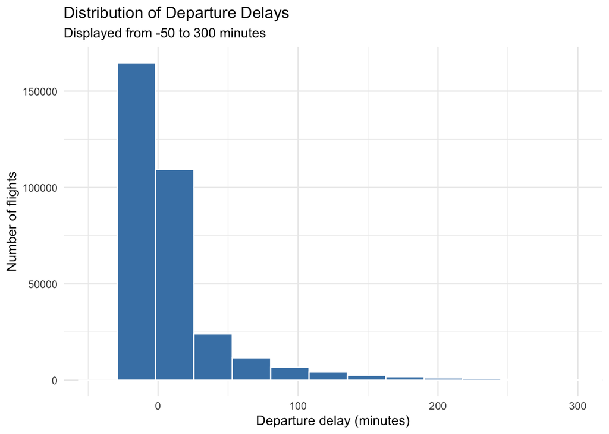

```r
library(tidyr)

ggplot(
  data = flights_weather,
  aes(x = dep_delay)
) +
  geom_histogram(
    bins = 50,
    fill = "steelblue",
    color = "white"
  ) +
  coord_cartesian(xlim = c(-50, 300)) +
  labs(
    title = "Distribution of Departure Delays",
    subtitle = "Displayed from -50 to 300 minutes",
    x = "Departure delay (minutes)",
    y = "Number of flights"
  ) +
  theme_minimal()
```

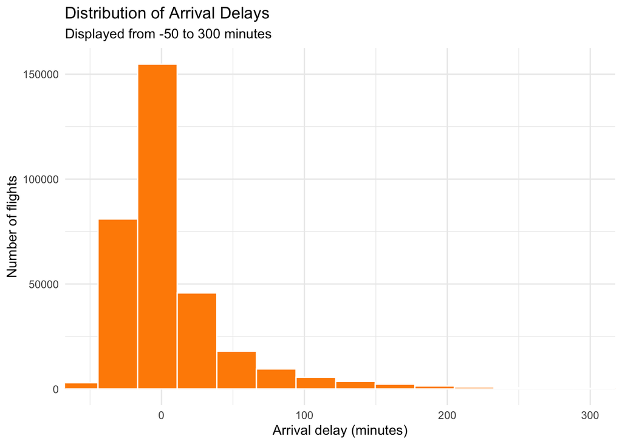

```r
# Distribution for arrival delay
ggplot(
  data = flights_weather,
  aes(x = arr_delay)
) +
  geom_histogram(
    bins = 50,
    fill = "darkorange",
    color = "white"
  ) +
  coord_cartesian(xlim = c(-50, 300)) +
  labs(
    title = "Distribution of Arrival Delays",
    subtitle = "Displayed from -50 to 300 minutes",
    x = "Arrival delay (minutes)",
    y = "Number of flights"
  ) +
  theme_minimal()
```

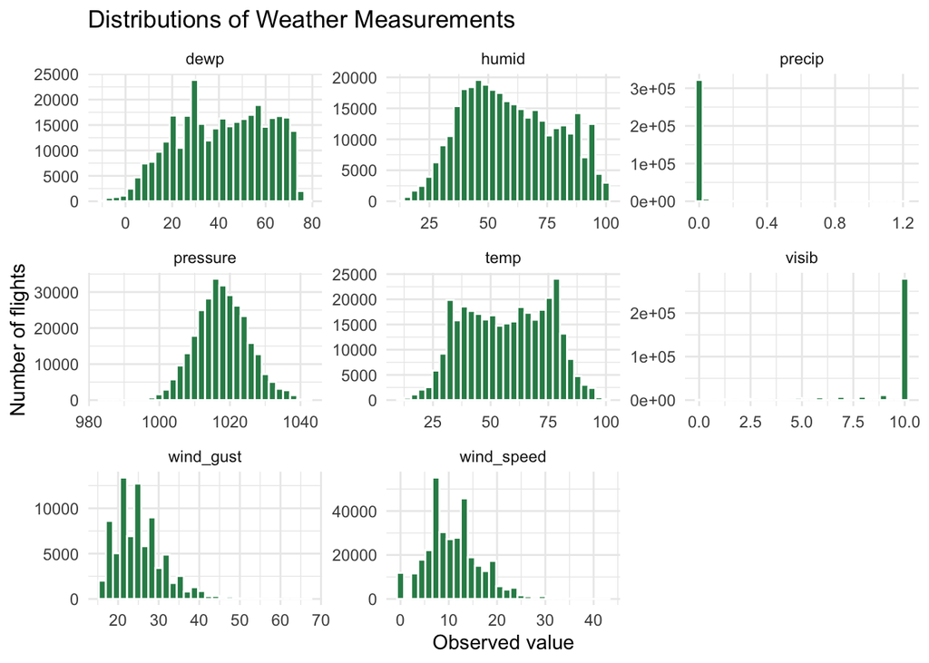

```r
weather_long <- flights_weather |>
  select(
    temp,
    dewp,
    humid,
    wind_speed,
    wind_gust,
    precip,
    pressure,
    visib
  ) |>
  pivot_longer(
    cols = everything(),
    names_to = "weather_variable",
    values_to = "value"
  ) |>
  filter(!is.na(value))

ggplot(
  data = weather_long,
  aes(x = value)
) +
  geom_histogram(
    bins = 30,
    fill = "seagreen",
    color = "white"
  ) +
  facet_wrap(
    ~weather_variable,
    scales = "free"
  ) +
  labs(
    title = "Distributions of Weather Measurements",
    x = "Observed value",
    y = "Number of flights"
  ) +
  theme_minimal()
```

When looking at the distribution for the departure delays, the data is heavily right skewed. This means that most flights departed either on time, slightly delayed, or earlier than scheduled, and that very few flights had long delays. When looking at the distribution for arrival delays, it shows that this distribution is also heavily right skewed. Most flights arrived either early, on time, or there was a very slight delay. Only a small number of flights arrived very delayed.

When looking at the distribution of weather measurements, there are different plots for the different variables. Precipitation is very concentrated at 0, meaning that most flights departed with no precipitation. Visibility is concentrated at 10 miles, meaning that most flights had maximum visibility. Pressure is approximately bell shaped around 1015. Both wind speed and gust are right skewed. Temperature, dew point, and humidity all have a wide range.

**Question 7**

```r
delay_data <- flights_weather |>
  filter(!is.na(dep_delay)) |>
  mutate(
    date = as.Date(
      time_hour,
      tz = "America/New_York"
    )
  )

daily_delays <- delay_data |>
  group_by(date) |>
  summarize(
    average_dep_delay = mean(dep_delay),
    number_of_flights = n(),
    .groups = "drop"
  ) |>
  arrange(desc(average_dep_delay))

worst_day <- daily_delays |>
  slice_max(
    average_dep_delay,
    n = 1,
    with_ties = FALSE
  )

daily_origin_delays <- delay_data |>
  group_by(date, origin) |>
  summarize(
    average_dep_delay = mean(dep_delay),
    number_of_flights = n(),
    .groups = "drop"
  ) |>
  arrange(desc(average_dep_delay))

worst_airport_day <- daily_origin_delays |>
  slice_max(
    average_dep_delay,
    n = 1,
    with_ties = FALSE
  )

hourly_origin_delays <- delay_data |>
  group_by(origin, time_hour) |>
  summarize(
    average_dep_delay = mean(dep_delay),
    number_of_flights = n(),
    .groups = "drop"
  ) |>
  arrange(desc(average_dep_delay))

worst_airport_hour <- hourly_origin_delays |>
  slice_max(
    average_dep_delay,
    n = 1,
    with_ties = FALSE
  )

worst_day
```

```
# A tibble: 1 × 3
  date       average_dep_delay number_of_flights
  <date>                 <dbl>             <int>
1 2013-03-08              83.5               799
```

```r
worst_airport_day
```

```
# A tibble: 1 × 4
  date       origin average_dep_delay number_of_flights
  <date>     <chr>              <dbl>             <int>
1 2013-03-08 LGA                 106.               229
```

```r
worst_airport_hour
```

```
# A tibble: 1 × 4
  origin time_hour           average_dep_delay number_of_flights
  <chr>  <dttm>                          <dbl>             <int>
1 LGA    2013-07-28 21:00:00              280.                 3
```

The day that had the worst average length of delay for departures was 03/08, with an average departure delay of 83.53 minutes. The airport that had the worst single day for delays was LGA, on 03/08, with an average delay of 105.72 minutes. The airport that had the worst single hour for delays was LGA on 07/28, at hour 21, with an average delay of 279.67 minutes.

**Question 8**

```r
library(tidyverse)
library(nycflights13)
library(leaflet)

destination_delays <- flights |>
  group_by(dest) |>
  summarize(
    average_arr_delay = mean(arr_delay, na.rm = TRUE),
    number_of_flights = sum(!is.na(arr_delay)),
    .groups = "drop"
  )

airports_delays <- airports |>
  left_join(
    destination_delays,
    by = c("faa" = "dest")
  ) |>
  filter(!is.na(average_arr_delay))

delay_colors <- colorNumeric(
  palette = "RdYlBu",
  domain = airports_delays$average_arr_delay,
  reverse = TRUE
)

leaflet(data = airports_delays) |>
  addTiles() |>
  addCircleMarkers(
    lng = ~lon,
    lat = ~lat,
    radius = 6,
    color = ~delay_colors(average_arr_delay),
    fillColor = ~delay_colors(average_arr_delay),
    fillOpacity = 0.8,
    stroke = FALSE,
    label = ~paste0(
      name,
      " (", faa, ")",
      ": ",
      round(average_arr_delay, 1),
      " minute average arrival delay"
    )
  ) |>
  addLegend(
    position = "bottomright",
    pal = delay_colors,
    values = ~average_arr_delay,
    title = "Average arrival<br>delay (minutes)",
    opacity = 1
  )
```

[interactive chart not shown]

**Question 9**

```r
library(tidyverse)

delay_weather <- flights_weather |>
  filter(!is.na(dep_delay))

# Temperature
temperature_summary <- delay_weather |>
  filter(!is.na(temp)) |>
  mutate(temp_group = ntile(temp, 10)) |>
  group_by(temp_group) |>
  summarize(
    average_temp = mean(temp),
    average_delay = mean(dep_delay),
    number_of_flights = n(),
    .groups = "drop"
  )

temperature_summary
```

```
# A tibble: 10 × 4
   temp_group average_temp average_delay number_of_flights
        <int>        <dbl>         <dbl>             <int>
 1          1         28.0         11.2              32698
 2          2         36.3         11.3              32698
 3          3         42.0         11.1              32698
 4          4         47.8          9.36             32698
 5          5         54.1          9.95             32698
 6          6         60.6         10.6              32698
 7          7         66.3         11.4              32697
 8          8         72.3         12.9              32697
 9          9         77.4         18.9              32697
10         10         85.3         19.7              32697
```

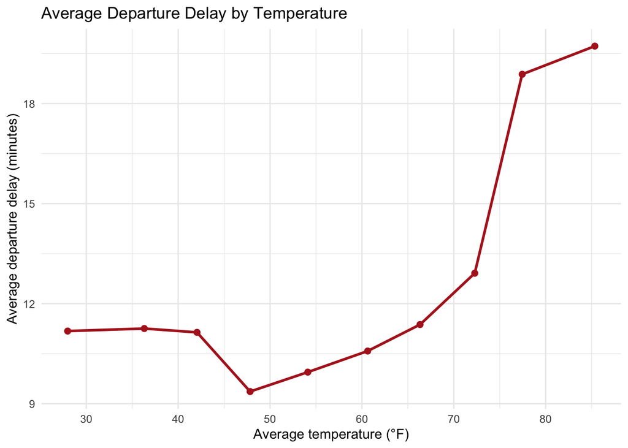

```r
ggplot(
  temperature_summary,
  aes(x = average_temp, y = average_delay)
) +
  geom_line(color = "firebrick", linewidth = 1) +
  geom_point(color = "firebrick", size = 2) +
  labs(
    title = "Average Departure Delay by Temperature",
    x = "Average temperature (°F)",
    y = "Average departure delay (minutes)"
  ) +
  theme_minimal()
```

```r
# Dewpoint
dewpoint_summary <- delay_weather |>
  filter(!is.na(dewp)) |>
  mutate(dewp_group = ntile(dewp, 10)) |>
  group_by(dewp_group) |>
  summarize(
    average_dewp = mean(dewp),
    average_delay = mean(dep_delay),
    number_of_flights = n(),
    .groups = "drop"
  )

dewpoint_summary
```

```
# A tibble: 10 × 4
   dewp_group average_dewp average_delay number_of_flights
        <int>        <dbl>         <dbl>             <int>
 1          1         8.27          9.04             32698
 2          2        19.2           8.95             32698
 3          3        26.2           8.71             32698
 4          4        32.0          11.6              32698
 5          5        39.3           9.39             32698
 6          6        45.8           9.79             32698
 7          7        52.1          10.9              32697
 8          8        57.8          13.4              32697
 9          9        64.1          17.8              32697
10         10        70.5          26.7              32697
```

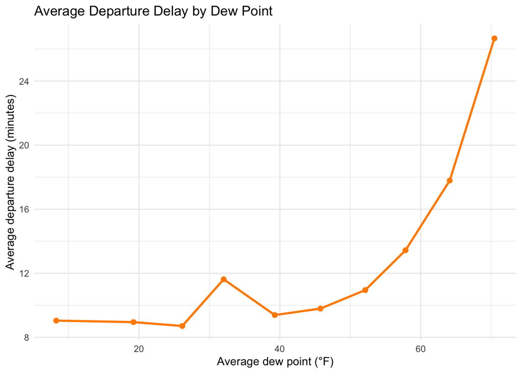

```r
ggplot(
  dewpoint_summary,
  aes(x = average_dewp, y = average_delay)
) +
  geom_line(color = "darkorange", linewidth = 1) +
  geom_point(color = "darkorange", size = 2) +
  labs(
    title = "Average Departure Delay by Dew Point",
    x = "Average dew point (°F)",
    y = "Average departure delay (minutes)"
  ) +
  theme_minimal()
```

```r
# Humidity
humidity_summary <- delay_weather |>
  filter(!is.na(humid)) |>
  mutate(humidity_group = ntile(humid, 10)) |>
  group_by(humidity_group) |>
  summarize(
    average_humidity = mean(humid),
    average_delay = mean(dep_delay),
    number_of_flights = n(),
    .groups = "drop"
  )

humidity_summary
```

```
# A tibble: 10 × 4
   humidity_group average_humidity average_delay number_of_flights
            <int>            <dbl>         <dbl>             <int>
 1              1             28.7          9.10             32698
 2              2             38.1          8.57             32698
 3              3             43.7          8.04             32698
 4              4             48.8          9.11             32698
 5              5             54.4          9.86             32698
 6              6             60.5         10.2              32698
 7              7             67.2         12.5              32697
 8              8             74.8         14.7              32697
 9              9             83.4         18.9              32697
10             10             92.7         25.4              32697
```

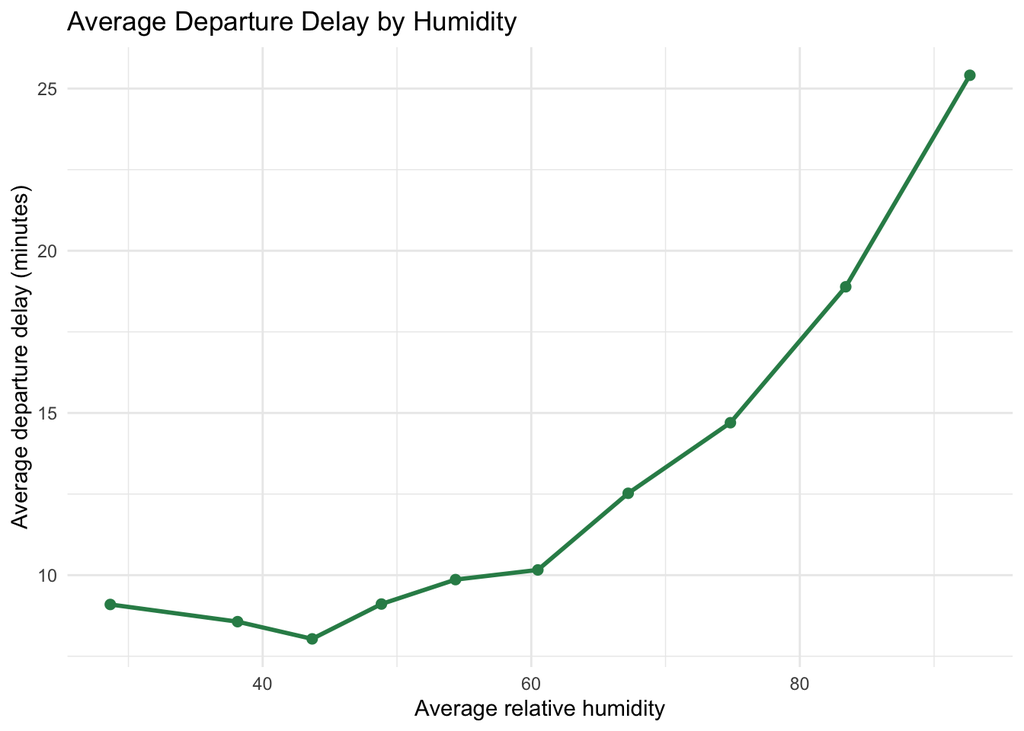

```r
ggplot(
  humidity_summary,
  aes(x = average_humidity, y = average_delay)
) +
  geom_line(color = "seagreen", linewidth = 1) +
  geom_point(color = "seagreen", size = 2) +
  labs(
    title = "Average Departure Delay by Humidity",
    x = "Average relative humidity",
    y = "Average departure delay (minutes)"
  ) +
  theme_minimal()
```

```r
# Wind direction
wind_direction_data <- delay_weather |>
  mutate(
    wind_direction = case_when(
      is.na(wind_dir) ~ NA_character_,
      wind_dir >= 337.5 | wind_dir < 22.5 ~ "N",
      wind_dir < 67.5 ~ "NE",
      wind_dir < 112.5 ~ "E",
      wind_dir < 157.5 ~ "SE",
      wind_dir < 202.5 ~ "S",
      wind_dir < 247.5 ~ "SW",
      wind_dir < 292.5 ~ "W",
      wind_dir < 337.5 ~ "NW"
    ),
    wind_direction = factor(
      wind_direction,
      levels = c("N", "NE", "E", "SE", "S", "SW", "W", "NW")
    )
  )

wind_direction_summary <- wind_direction_data |>
  filter(!is.na(wind_direction)) |>
  group_by(wind_direction) |>
  summarize(
    average_delay = mean(dep_delay),
    median_delay = median(dep_delay),
    number_of_flights = n(),
    .groups = "drop"
  )

wind_direction_summary
```

```
# A tibble: 8 × 4
  wind_direction average_delay median_delay number_of_flights
  <fct>                  <dbl>        <dbl>             <int>
1 N                      10.3            -2             44931
2 NE                     11.1            -2             31400
3 E                      16.7            -1             18129
4 SE                     18.4            -1             20686
5 S                      16.7            -1             49984
6 SW                     13.2            -1             43261
7 W                      11.3            -1             54317
8 NW                      9.09           -2             56212
```

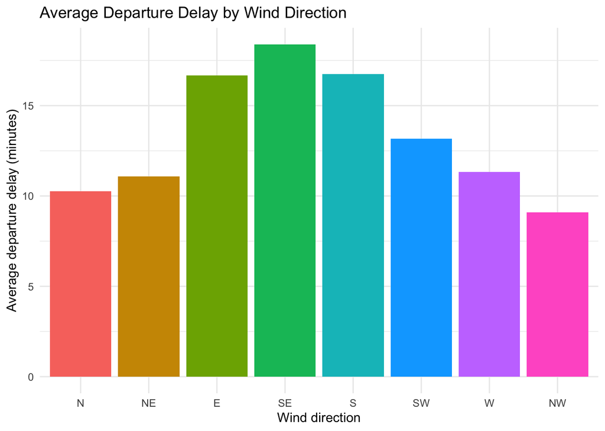

```r
ggplot(
  wind_direction_summary,
  aes(
    x = wind_direction,
    y = average_delay,
    fill = wind_direction
  )
) +
  geom_col(show.legend = FALSE) +
  labs(
    title = "Average Departure Delay by Wind Direction",
    x = "Wind direction",
    y = "Average departure delay (minutes)"
  ) +
  theme_minimal()
```

```r
# Wind speed
wind_speed_data <- delay_weather |>
  mutate(
    wind_condition = case_when(
      is.na(wind_speed) ~ NA_character_,
      wind_speed < 10 ~ "Low wind",
      wind_speed < 20 ~ "Moderate wind",
      wind_speed >= 20 ~ "Strong wind"
    ),
    wind_condition = factor(
      wind_condition,
      levels = c("Low wind", "Moderate wind", "Strong wind")
    )
  )

wind_speed_summary <- wind_speed_data |>
  filter(!is.na(wind_condition)) |>
  group_by(wind_condition) |>
  summarize(
    average_delay = mean(dep_delay),
    median_delay = median(dep_delay),
    number_of_flights = n(),
    .groups = "drop"
  )

wind_speed_summary
```

```
# A tibble: 3 × 4
  wind_condition average_delay median_delay number_of_flights
  <fct>                  <dbl>        <dbl>             <int>
1 Low wind                11.0           -2            146283
2 Moderate wind           13.6           -1            160644
3 Strong wind             16.9            0             19988
```

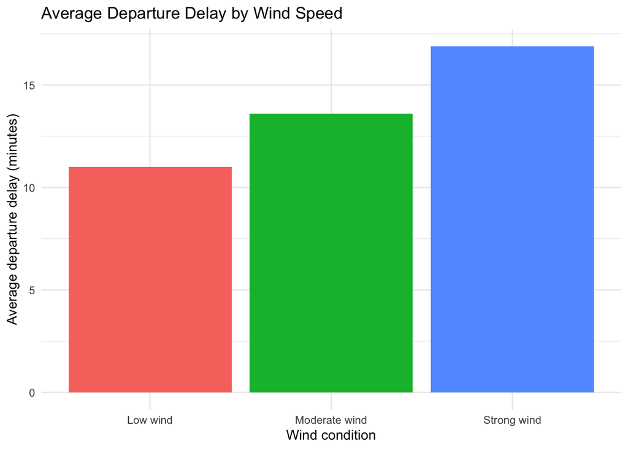

```r
ggplot(
  wind_speed_summary,
  aes(
    x = wind_condition,
    y = average_delay,
    fill = wind_condition
  )
) +
  geom_col(show.legend = FALSE) +
  labs(
    title = "Average Departure Delay by Wind Speed",
    x = "Wind condition",
    y = "Average departure delay (minutes)"
  ) +
  theme_minimal()
```

```r
# Wind gust
wind_gust_summary <- delay_weather |>
  filter(!is.na(wind_gust)) |>
  mutate(wind_gust_group = ntile(wind_gust, 10)) |>
  group_by(wind_gust_group) |>
  summarize(
    average_wind_gust = mean(wind_gust),
    average_delay = mean(dep_delay),
    number_of_flights = n(),
    .groups = "drop"
  )

wind_gust_summary
```

```
# A tibble: 10 × 4
   wind_gust_group average_wind_gust average_delay number_of_flights
             <int>             <dbl>         <dbl>             <int>
 1               1              17.3          10.7              7774
 2               2              19.2          12.5              7774
 3               3              20.9          12.4              7774
 4               4              22.3          11.5              7774
 5               5              23.6          15.3              7773
 6               6              24.9          15.9              7773
 7               7              26.5          13.0              7773
 8               8              28.2          12.8              7773
 9               9              31.0          13.7              7773
10              10              37.6          18.7              7773
```

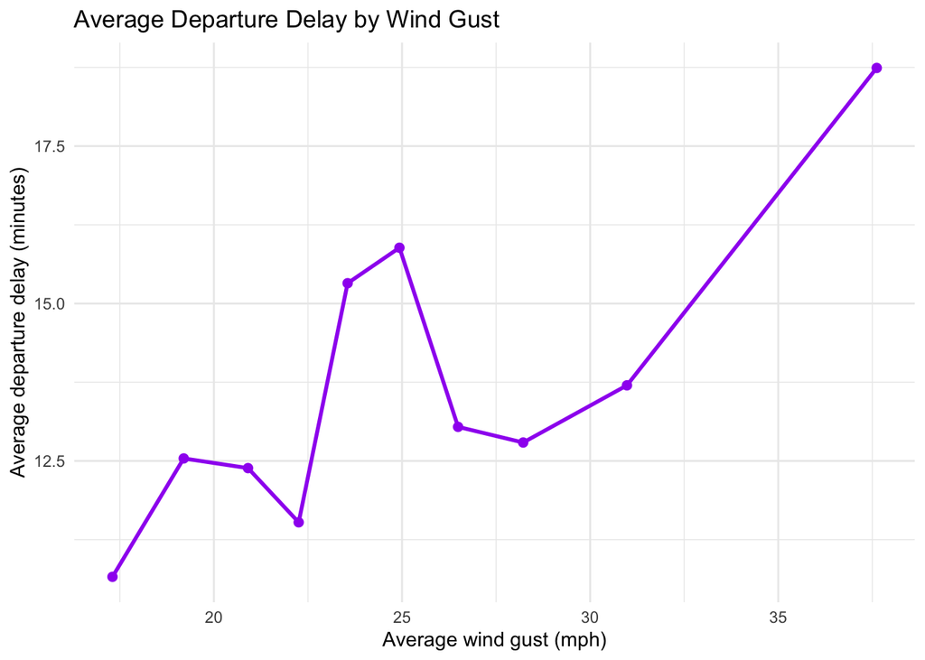

```r
ggplot(
  wind_gust_summary,
  aes(x = average_wind_gust, y = average_delay)
) +
  geom_line(color = "purple", linewidth = 1) +
  geom_point(color = "purple", size = 2) +
  labs(
    title = "Average Departure Delay by Wind Gust",
    x = "Average wind gust (mph)",
    y = "Average departure delay (minutes)"
  ) +
  theme_minimal()
```

```r
# Precipitation
precipitation_data <- delay_weather |>
  mutate(
    precipitation_condition = case_when(
      is.na(precip) ~ NA_character_,
      precip == 0 ~ "No precipitation",
      precip <= 0.10 ~ "Light precipitation",
      precip > 0.10 ~ "Heavy precipitation"
    ),
    precipitation_condition = factor(
      precipitation_condition,
      levels = c(
        "No precipitation",
        "Light precipitation",
        "Heavy precipitation"
      )
    )
  )

precipitation_summary <- precipitation_data |>
  filter(!is.na(precipitation_condition)) |>
  group_by(precipitation_condition) |>
  summarize(
    average_delay = mean(dep_delay),
    median_delay = median(dep_delay),
    number_of_flights = n(),
    .groups = "drop"
  )

precipitation_summary
```

```
# A tibble: 3 × 4
  precipitation_condition average_delay median_delay number_of_flights
  <fct>                           <dbl>        <dbl>             <int>
1 No precipitation                 11.4           -2            305907
2 Light precipitation              28.8            4             17346
3 Heavy precipitation              40.9           11              3740
```

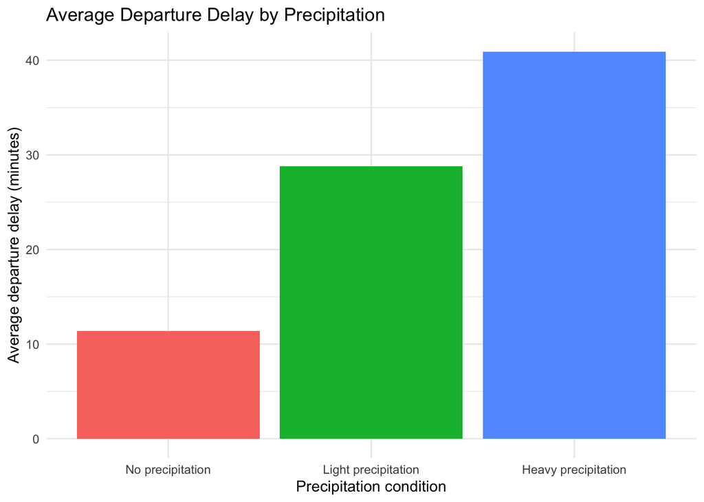

```r
ggplot(
  precipitation_summary,
  aes(
    x = precipitation_condition,
    y = average_delay,
    fill = precipitation_condition
  )
) +
  geom_col(show.legend = FALSE) +
  labs(
    title = "Average Departure Delay by Precipitation",
    x = "Precipitation condition",
    y = "Average departure delay (minutes)"
  ) +
  theme_minimal()
```

```r
# Pressure
pressure_summary <- delay_weather |>
  filter(!is.na(pressure)) |>
  mutate(pressure_group = ntile(pressure, 10)) |>
  group_by(pressure_group) |>
  summarize(
    average_pressure = mean(pressure),
    average_delay = mean(dep_delay),
    number_of_flights = n(),
    .groups = "drop"
  )

pressure_summary
```

```
# A tibble: 10 × 4
   pressure_group average_pressure average_delay number_of_flights
            <int>            <dbl>         <dbl>             <int>
 1              1            1005.         19.4              29221
 2              2            1010.         19.2              29221
 3              3            1013.         11.7              29220
 4              4            1015.         12.0              29220
 5              5            1017.         11.6              29220
 6              6            1019.          9.55             29220
 7              7            1021.          7.78             29220
 8              8            1023.          7.55             29220
 9              9            1026.          6.64             29220
10             10            1031.          5.97             29220
```

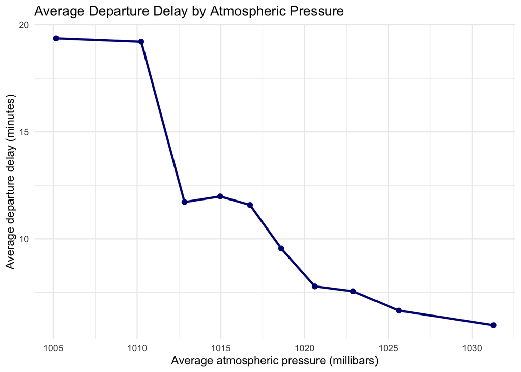

```r
ggplot(
  pressure_summary,
  aes(x = average_pressure, y = average_delay)
) +
  geom_line(color = "navy", linewidth = 1) +
  geom_point(color = "navy", size = 2) +
  labs(
    title = "Average Departure Delay by Atmospheric Pressure",
    x = "Average atmospheric pressure (millibars)",
    y = "Average departure delay (minutes)"
  ) +
  theme_minimal()
```

```r
# Visibility
visibility_data <- delay_weather |>
  mutate(
    visibility_condition = case_when(
      is.na(visib) ~ NA_character_,
      visib < 5 ~ "Low visibility",
      visib < 10 ~ "Reduced visibility",
      visib >= 10 ~ "Clear visibility"
    ),
    visibility_condition = factor(
      visibility_condition,
      levels = c(
        "Clear visibility",
        "Reduced visibility",
        "Low visibility"
      )
    )
  )

visibility_summary <- visibility_data |>
  filter(!is.na(visibility_condition)) |>
  group_by(visibility_condition) |>
  summarize(
    average_delay = mean(dep_delay),
    median_delay = median(dep_delay),
    number_of_flights = n(),
    .groups = "drop"
  )

visibility_summary
```

```
# A tibble: 3 × 4
  visibility_condition average_delay median_delay number_of_flights
  <fct>                        <dbl>        <dbl>             <int>
1 Clear visibility              11.0           -2            273660
2 Reduced visibility            19.6           -1             35812
3 Low visibility                24.8            1             17521
```

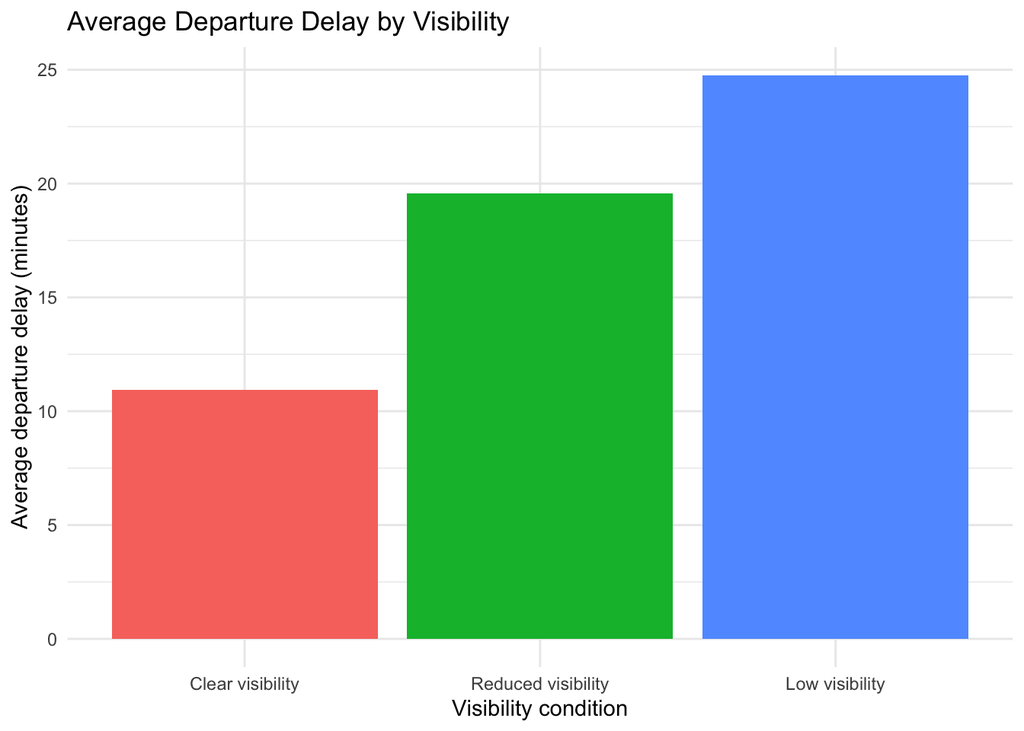

```r
ggplot(
  visibility_summary,
  aes(
    x = visibility_condition,
    y = average_delay,
    fill = visibility_condition
  )
) +
  geom_col(show.legend = FALSE) +
  labs(
    title = "Average Departure Delay by Visibility",
    x = "Visibility condition",
    y = "Average departure delay (minutes)"
  ) +
  theme_minimal()
```

```r
# Correlation for weather variables without wind direction because its circular
weather_correlations <- delay_weather |>
  summarize(
    across(
      c(
        temp,
        dewp,
        humid,
        wind_speed,
        wind_gust,
        precip,
        pressure,
        visib
      ),
      ~cor(dep_delay, .x, use = "complete.obs")
    )
  ) |>
  pivot_longer(
    cols = everything(),
    names_to = "weather_variable",
    values_to = "correlation"
  ) |>
  arrange(desc(abs(correlation)))

weather_correlations
```

```
# A tibble: 8 × 2
  weather_variable correlation
  <chr>                  <dbl>
1 humid                 0.117
2 pressure             -0.114
3 dewp                  0.102
4 visib                -0.0941
5 precip                0.0904
6 temp                  0.0615
7 wind_speed            0.0474
8 wind_gust             0.0413
```

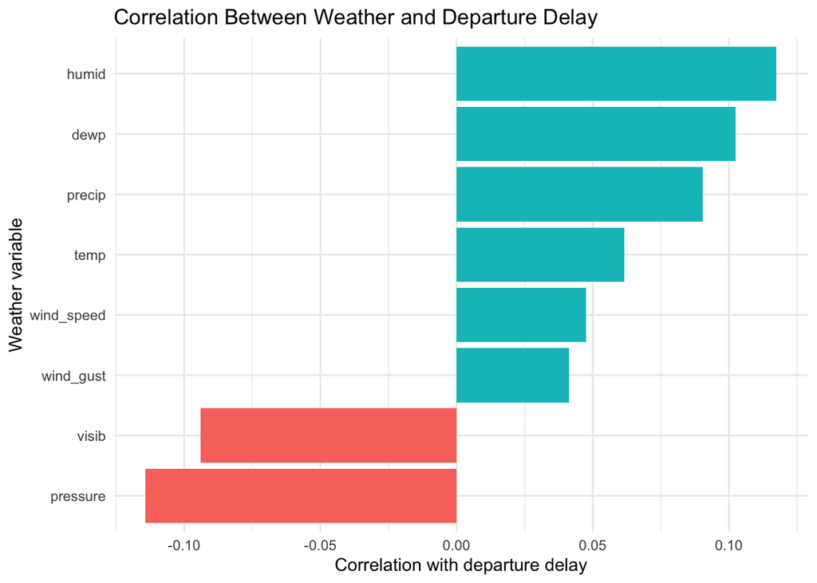

```r
ggplot(
  weather_correlations,
  aes(
    x = reorder(weather_variable, correlation),
    y = correlation,
    fill = correlation > 0
  )
) +
  geom_col(show.legend = FALSE) +
  coord_flip() +
  labs(
    title = "Correlation Between Weather and Departure Delay",
    x = "Weather variable",
    y = "Correlation with departure delay"
  ) +
  theme_minimal()
```

When looking at the graph ‘average departure delay by temperature,’ we can see how average departure delay varied across different temperatures. We can see that the average departure delay is the lowest around 47 degrees Fahrenheit. Anything colder than this has average delays around 11 minutes. At temperatures above this point, the average departure delay generally increased. There was a big spike in delay between approximately 72 and 76 degrees Fahrenheit. The highest temperature group was associated with the longest average departure delay.

When looking at the graph including dew point, we can see that the average departure delay remained fairly consistent up to approximately 30 degrees Fahrenheit. Around 32 degrees, the average departure delay increased to almost 12 minutes. It then decreased around 39 degrees before generally increasing as the dew point rose further. The largest increase in average departure delay occurred at the highest dew point values.

When looking at the graph including average relative humidity, we can see that average departure delay remained relatively low when average relative humidity was below approximately 60%. Above 60% humidity, average departure delay generally increased. The increase was especially large at the highest humidity levels, with the highest average relative humidity being associated with an average departure delay of approximately 25 minutes. Therefore, higher humidity was associated with longer average departure delays.

When looking at the graph including wind direction, we can see that South East winds were associated with the longest average departure delay at approximately 18 minutes. East and South winds were also associated with relatively long average delays of approximately 17 minutes. North West winds were associated with the shortest average delay at approximately 9 minutes. Overall, average departure delays varied depending on wind direction.

When looking at the plot with the wind conditions, we can see that the average departure delay with low winds was about 11 minutes, with moderate wind about 13 minutes, and with strong wind about 17 minutes. Thus, stronger winds were associated with longer average departure delays.

When looking at the plot with average wind gust, we can see that average departure delay fluctuates across the lower and moderate wind gust values. There is a noticeable increase in average delay between approximately 22 and 24 mph, followed by a decrease between approximately 25 and 28 mph. The strongest wind gust group, at approximately 38 mph, was associated with the longest average departure delay at approximately 19 minutes. Overall, stronger wind gusts were generally associated with longer departure delays, although this relationship was not completely consistent.

When looking at the plot with precipitation condition and average delay, we can see that the average delay with heavy precipitation is approximately 41 minutes, with light precipitation approximately 29 minutes, and with no precipitation about 11 minutes. Thus, heavier precipitation was associated with longer average departure delays.

When looking at the graph with atmospheric pressure, we can see that lower atmospheric pressure were associated with longer average departure delays. The two lowest pressure groups, at approximately 1005 and 1010 millibars, had average delays of about 19 minutes. As atmospheric pressure increased, the average departure delay generally decreased. The highest pressure group, at approximately 1031 millibars, was associated with the the shortest average delay of about 6 minutes.

When looking at the plot with visibility conditions, the average departure delay with clear visibility was approximately 11 minutes, with low visibility approximately 25 minutes, and with reduced visibility approximately 20 minutes. This suggests that worse visibility was associated with longer average departure delays.

The last graph plots the correlation coefficients between departure delay and each weather variable. Both visibility and pressure have a negative correlation with departure delay, meaning that if visibility or pressure increases, departure delay generally decreases. Humidity has the strongest correlation coefficient of 0.117. Among the variables with positive correlations, humidity was followed by dew point, precipitation, temperature, wind speed, and wind gust. Wind direction was not included in the correlation analysis because it is a circular variable.

After looking at all the graphs, we can conclude that precipitation showed the largest difference in average departure delay. High humidity, high dew point, low atmospheric pressure, low visibility, and strong winds were also associated with longer average delays. Southeast winds were associated with the longest average delay among the wind directions. However, because all correlation coefficients were weak, weather conditions alone do not explain departure delays. There are other factors that might also be associated with departure delays.